# Problema 1 - Checkpoint 1

Davi Laerte

May 22, 2017

## Apresentação

Nesse pequeno estudo, para a discplina de **Análise de Dados 1(UFCG)**, usarei os [dados](https://raw.githubusercontent.com/nazareno/imdb-series/master/data/series_from_imdb.csv) coletados do IMDB sobre pouco mais de 30 séries de TV e pretendo escolher três séries para responder as seguintes perguntas:

1. Qual das séries é mais bem avaliada no IMDB? A diferença é grande? Pequena?
2. Qual das séries que você escolheu tem episódios de qualidade mais irregular segundo o IMDB? A diferença é grande? Pequena?

```r
# carregando a biblioteca e lendo os dados.

library(tidyverse)
dados_series <- read.csv("https://raw.githubusercontent.com/nazareno/imdb-series/master/data/series_from_imdb.csv", sep = ",")
```

## Escolhendo as séries

Dando uma olhada nas séries coletadas, decidi por escolher essas três séries:

```r
# filtrando as séries escolhidas.

series_escolhidas <- dados_series %>% filter(series_name %in% c("Vikings", "Game of Thrones", "House of Cards"))
head(series_escolhidas %>% distinct(series_name))
```

```
##       series_name
## 1  House of Cards
## 2 Game of Thrones
## 3         Vikings
```

Pelo fato de já ter assistido as três e ter gostado bastante delas(*recomendo*).

## Respondendo a primeira pergunta

Muito bem, terminada a escolha das três séries tentarei responder a seguinte questão:

1.Qual das séries é mais bem avaliada no IMDB? A diferença é grande? Pequena?

### Gráfico de avaliações dos usuários por número de episódios

Para responder a primeira questão darei uma olhada nos dados através de um grafico de avaliações dos usuários pelo número de episódios com as três séries separadas pela cor.

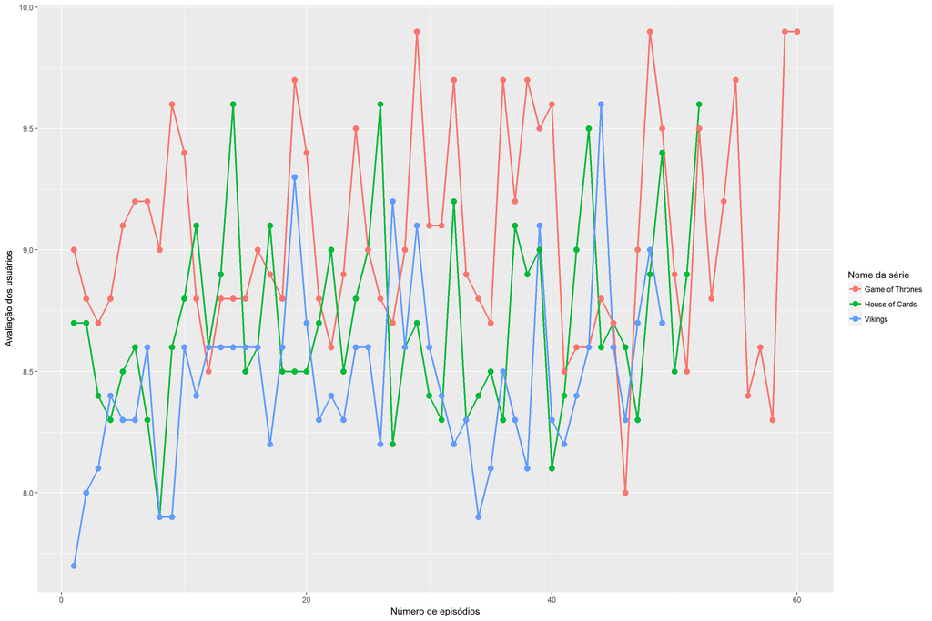

```r
# criando o plot do gráfico de avaliações dos usuarios por número de episódios.

ggplot(data = series_escolhidas, aes(x=series_ep, y=UserRating, group=series_name, colour=series_name)) +
labs(colour = "Nome da série") +
labs(x = "Número de episódios") +
labs(y = "Avaliação dos usuários") +
geom_line(size = 1) +
geom_point(size = 3)
```

Dando uma olhada no gráfico percebe-se que **Game of Thrones** e a série que tem as avaliações mais altas, em seus episódios, em relação as outras séries seguida de **House of Cards** e por ultimo **Vikings**.

Ao se analisar melhor o gráfico também se percebe que apesar de **Game of Thrones** ter mais episódios bem avaliados a diferença de avaliação por episódio entre as séries é bem pequena, principalmente entre **House of Cards** e **Vikings**, tendo algumas vezes os episódios de **House of Cards** e **Vikings** sendo mais bem avaliados que os de **Game of Thrones**.

### Tabela da média e mediana de avaliações

Para comprovar as hipóteses vistas no gráfico acima, vou usar algumas ferramentas estatísticas, a média e a mediana, para ter uma ideia de onde estão os valores médios das avaliações dessas séries, para tanto farei uma tabela com as séries e suas respectivas média e mediana das avaliações.

```r
# gerando a tabela da média e mediana das avaliações.

series_summarizadas = series_escolhidas %>% group_by(series_name) %>% summarise(avaliacoes_media = mean(UserRating), avaliacoes_mediana = median(UserRating), numero_de_episodios = n())
head(series_summarizadas)
```

```
## # A tibble: 3 x 4
##       series_name avaliacoes_media avaliacoes_mediana numero_de_episodios
##            <fctr>            <dbl>              <dbl>               <int>
## 1 Game of Thrones         9.046667               8.95                  60
## 2  House of Cards         8.705769               8.60                  52
## 3         Vikings         8.473469               8.40                  49
```

Analisando a tabela comprova-se o que foi visto no gráfico, os valores tanto da média como da mediana das avaliações de **Game of Thrones** são maiores que os das outras séries em seguida vem **House of Cards** e por ultimo **Vikings**, também percebe-se melhor que as diferenças entre as avaliações das séries são bem pequenas onde a maior diferença entre a média é de 0.57 e entre a mediana é de 0.55, das séries **Game of Thrones** e **Vikings**.

### Resposta da primeira pergunta

Assim analisando os dados cheguei a conclusão que **Game of Thrones** é a série mais bem avaliada(*é boa mesmo*) segundo o IMDB e que as diferenças entre as avaliações da são bem pequenas(*todas são muito boas*).

## Respondendo a segunda pergunta

Terminado de Responder a primeira questão, vou para a segunda:

2.Qual das séries que você escolheu tem episódios de qualidade mais irregular segundo o IMDB? A diferença é grande? Pequena?

### Tabela do desvio padrão e IQR das avaliações

Para saber qual série tem a qualidade mais irregular, precisarei de uma medida que de uma ideia de quanto as avaliações de cada série variou em relação a média durante os seus episódios, ou seja qual o grau de espalhamento das avaliações em relação a média, para tanto usarei novamente duas ferramentas estatísticas o desvio padrão e o IQR, que servem para medir o grau de espalhamento em torno da medida de centralidade, para tanto construirei uma tabela com as séries e seus respectivos desvio padrão e IQR das avaliações.

```r
# gerando a tabela do descio padrão e IQR das avaliações.

series_variacao_summarizadas = series_escolhidas %>% group_by(series_name) %>% summarise(desvio_padrao = sd(UserRating), IQR = IQR(UserRating), numero_de_episodios = n())
head(series_variacao_summarizadas)
```

```
## # A tibble: 3 x 4
##       series_name desvio_padrao   IQR numero_de_episodios
##            <fctr>         <dbl> <dbl>               <int>
## 1 Game of Thrones     0.4492807 0.625                  60
## 2  House of Cards     0.3907828 0.450                  52
## 3         Vikings     0.3740407 0.300                  49
```

### Gráficos do desvio padrão e IQR por série

Para melhor visualização construirei um gráfico das séries pelos seu Desvio padrão:

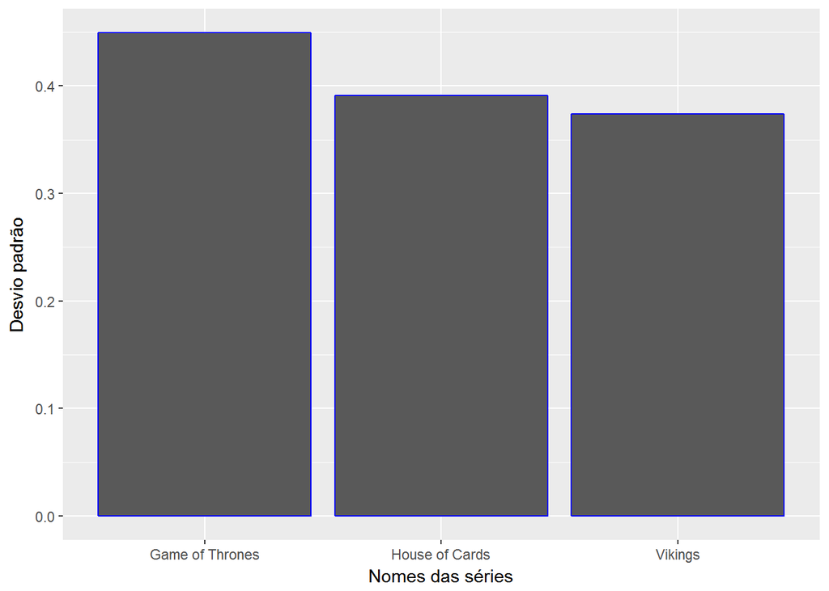

```r
# criando o plot do gráfico das séries pelo seu desvio padrão.

ggplot(data = series_variacao_summarizadas, aes(x=series_name, y=desvio_padrao)) +
labs(x = "Nomes das séries") +
labs(y = "Desvio padrão") +
geom_col(color = 'blue')
```

É um grafico das séries pelos seu IQR:

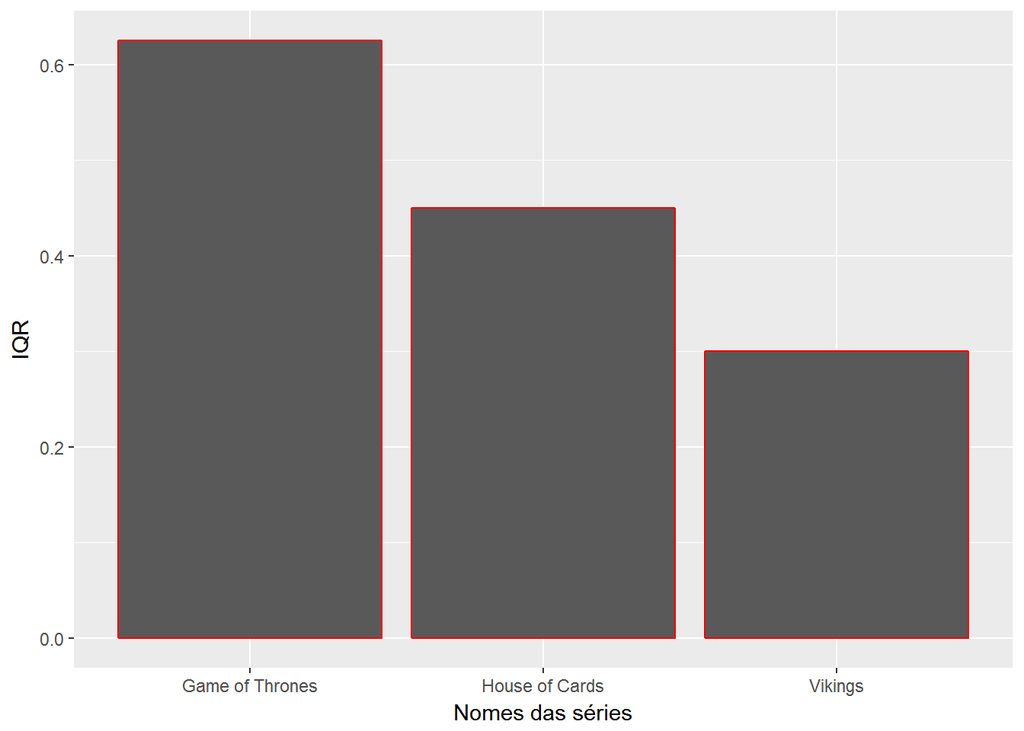

```r
# criando o plot do gráfico das séries pelo seu IQR.

ggplot(data = series_variacao_summarizadas, aes(x=series_name, y=IQR)) +
labs(x = "Nomes das séries") +
labs(y = "IQR") +
geom_col(color = 'red')
```

Analisando os dados acima e tendo em vista que quanto menor o desvio padrão e o IQR, menor a quantidade de espalhamento dos dados em relação a medida central, a série que aprensentou menor desvio padrão e menor IQR foi **Vikings** seguida de **House ou Cards** e por Ultimo **Game of Thrones**, as diferenças entre as séries são pequenas tanto seus desvios padrões como seus IQR são próximos.

### Resposta da segunda pergunta

Tendo em vista os dados analisados, cheguei a conclusão que a série com episódios de qualidade mais irregular é **Game of Thrones**, pois as avaliações dos seus episódios estão mais espalhados em relação a medida central, mesmo assim todas a séries analisadas tem variação de qualidade muito pequena entre seus episódios e a diferença das variações, entre as séries, são baixas e próximas.